# STAT 151A Lab 07

Billy Fang

October 13, 2017

As always, feel free to leave anonymous feedback here: https://goo.gl/forms/fKjLeKItix2Djg5l2

# Lecture review, notation/terminology clarification

**Relevant reading: Parts of sections 11.3 and 11.4**

- **Residuals:** $\widehat{e} := y - X \widehat{\beta} = (I - H)y$ where $H=X (X^\top X)^{-1} X^\top$. **Exercises:** Under our standard Gaussian model, what is the distribution of $\widehat{e}$? What is the distribution of $\widehat{e}_i$?
- **Standardized residuals**: the $i$th standardized residual is
  $$r_i := \frac{\widehat{e}_i}{\widehat{\sigma} \sqrt{1 - h_i}}$$
  (denoted as $E'_i$ in the textbook). **Exercises:** What is the intuition behind why we might define this quantity this way? What does it measure? What is a drawback of this quantity?
- **Predicted residuals**: the $i$th predicted residual is
  $$\widehat{e}_{[i]} := y_i - x_i^\top \widehat{\beta}_{[i]},$$
  where $\widehat{\beta}_{[i]}$ is the least squares coefficients vector from using the reduced dataset $y_{[i]}$ and $X_{[i]}$, and where $y_{[i]}$ and $X_{[i]}$ are obtained by deleting the $i$th entry and $i$th row respectively (effectively, removing the $i$th observation in the dataset). Some related facts:
  - The Woodbury matrix formula allows us to write down an expression for $\widehat{\beta}_{[i]}$ in terms of quantities in the original regression, which avoids having to do a regression for every possible leave-one-out reduced dataset.
    $$\widehat{\beta}_{[i]} = \widehat{\beta} - \frac{\widehat{e}_i}{1 - h_i} (X^\top X)^{-1} x_i \tag{1}$$
  - This in turn leads to a formula for the predicted residual that again avoids using quantities from the regressions on the reduced datasets.
    $$\widehat{e}_{[i]} = \frac{\widehat{e}_i}{1 - h_i}.$$
    **Exercise:** What is the variance of $\widehat{e}_{[i]}$?
- Using equation (1) above along with some tedious computation, one can also prove the following useful expression that appears in your lecture notes.
  $$\text{RSS}_{[i]} = \text{RSS} - \frac{\widehat{e}_i^2}{1 - h_i},$$
  where $\text{RSS}_{[i]}$ is the RSS from the fit on the reduced dataset
- **Standardized predicted residuals**:
  $$t_i = \frac{\widehat{e}_{[i]} \sqrt{1-h_i}}{\sqrt{\text{RSS}_{[i]} / (n - p - 2)}}$$
  - Your textbook and R call these studentized residuals (but in the lecture notes, these are called **externally studentized residuals**, and studentized residuals refers to standardized residuals) and use the notation $E^*_i$. They give a seemingly different formula:
    $$E^*_i := \frac{\widehat{e}_i}{\widehat{\sigma}_{[i]} \sqrt{1-h_i}},$$
    where $\widehat{\sigma}_{[i]} := \sqrt{\text{RSS}_{[i]} / (n - p - 2)}$ is the estimate for the variance using the reduced dataset. **Exercise:** Show that indeed $E^*_i = t_i$.
  - Following its name, $t_i$ follows a $t$-distribution with $n-p-2$ degrees of freedom. To see this note that $\widehat{e}_{[i]}$ depends only on $e_i$ and $\widehat{\beta}_{[i]}$, which are independent of $\widehat{\sigma}_{[i]}$.
  - Your textbook and your homework also provide the following relationship between the standardized predicted residuals and the standardized residuals.
    $$t_i = r_i \sqrt{\frac{n - p - 2}{n - p - 1 - r_i^2}}$$
- **Cook’s distance:** measuring influence by how much $\widehat{\beta}$ differs from $\widehat{\beta}_{[i]}$
  - In lecture: perhaps try $\|\widehat{\beta} - \widehat{\beta}_{[i]}\|^2$? But this ignores the correlation structure of $\widehat{\beta}$. Correct this by using Mahalanobis distance instead.
  - Equivalent way of understanding the “derivation” of Cook’s distance: inspiration from $F$-statistic. Suppose we want to test the “hypothesis”
    $$\beta = \widehat{\beta}_{[i]}.$$
    This can be written in the form $L \beta = c$ with $L = I_{p+1}$ and $c = \widehat{\beta}_{[i]}$, so if we use our long formula for the $F$-statistic for the general linear hypothesis $L \beta = c$, we get
    $$\frac{(L\widehat{\beta} - c)^\top [L(X^\top X)^{-1} L^\top]^{-1} (L \widehat{\beta} - c)\; /\; (p+1)}{\widehat{\sigma}^2}
    = \frac{(\widehat{\beta} - \widehat{\beta}_{[i]})^\top (X^\top X) (\widehat{\beta} - \widehat{\beta}_{[i]})}{(p+1) \widehat{\sigma}^2}=: C_i$$
    which is the quantity from lecture. Why is this not really an $F$-statistic?
  - The textbook and your lecture notes offer another formula for Cook’s distance.
    $$C_i = \frac{r_i^2}{p+1} \cdot \frac{h_i}{1 - h_i}.$$
    **Exercise:** show that both formulas are the same.

For #3 on the homework, you may use `lm()` to compute familiar quantities (residuals, fitted values), but please use them to manually compute the new quantities (std. residuals, pred. residuals, std. pred. residuals, Cook’s distance). You may use R functions to check that your computations are correct.

# Examples in simple regression

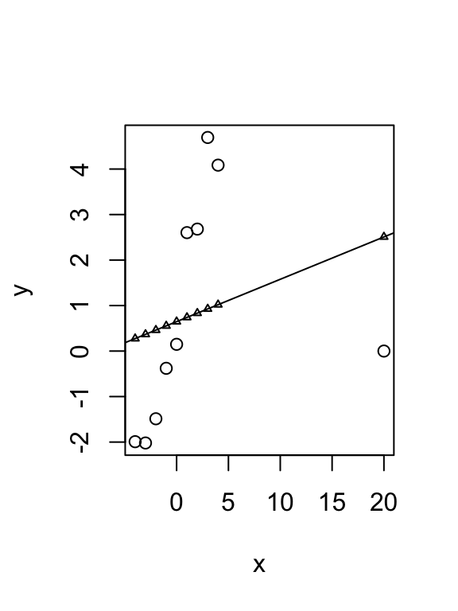

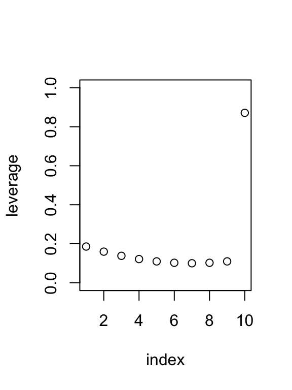

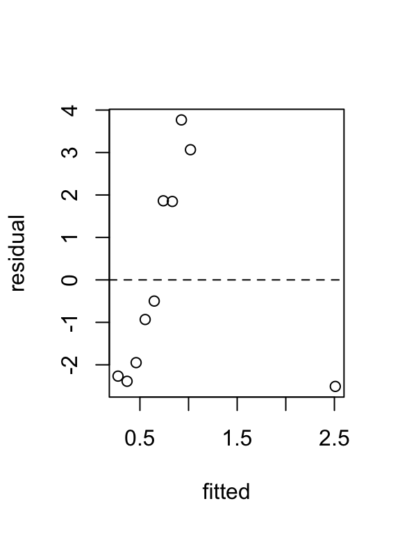

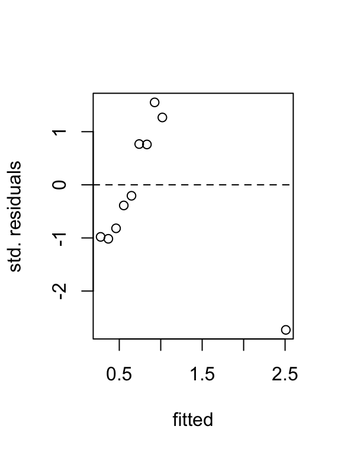

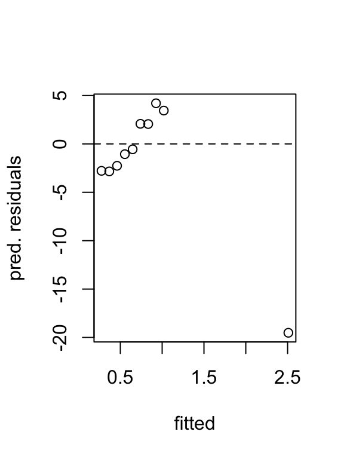

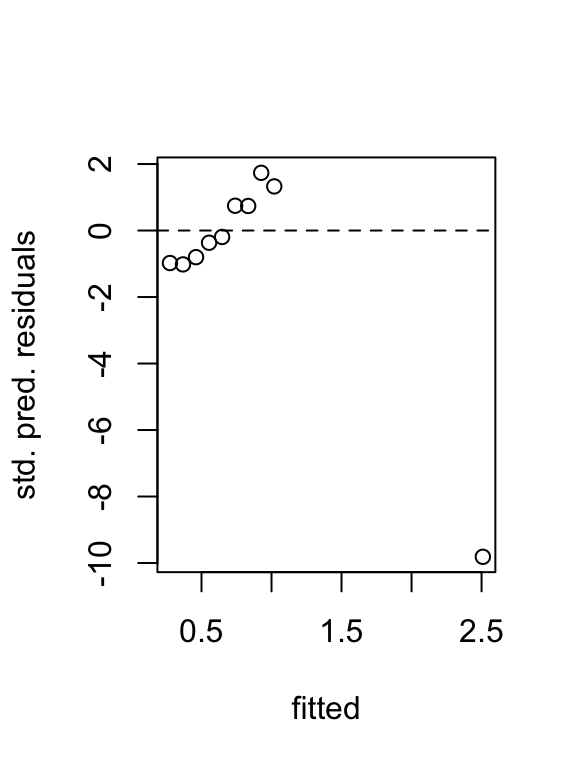

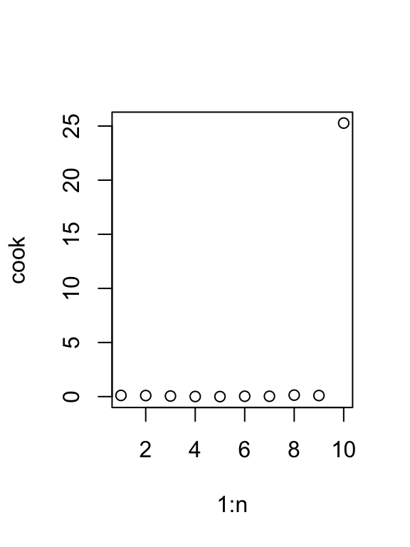

```r
x <- c((-4):4, 20)
n <- length(x)
p <- 1
y <- x + 1 + rnorm(n, sd=0.5)
y[n] <- 0
MakePlots(x, y) # custom function that I wrote
```

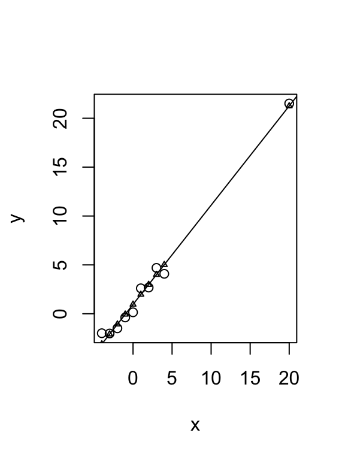

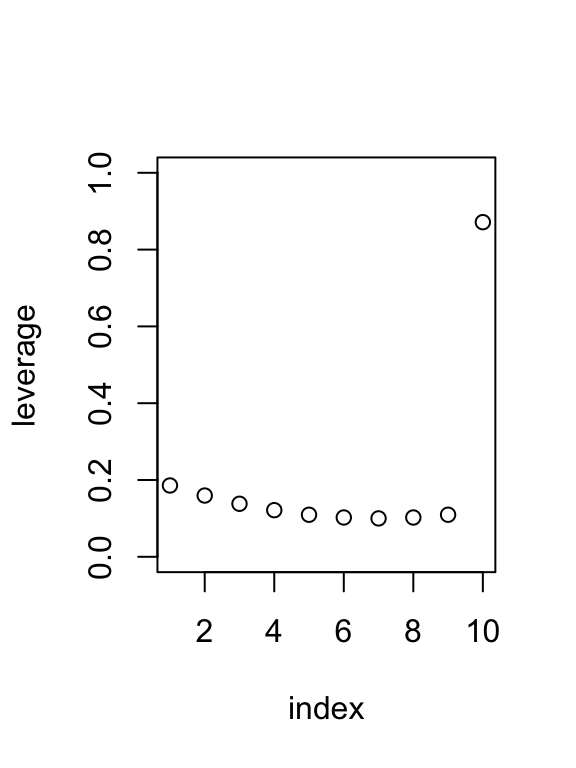

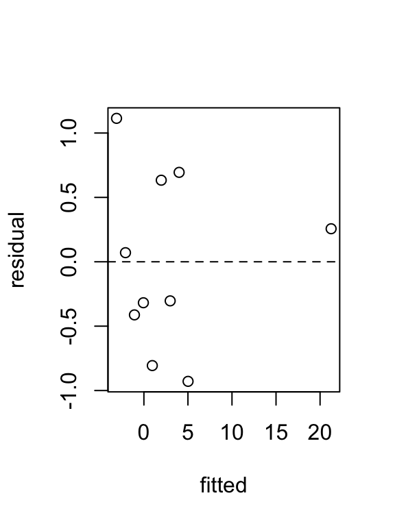

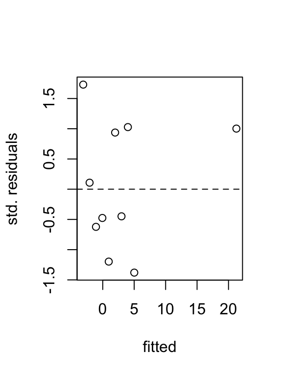

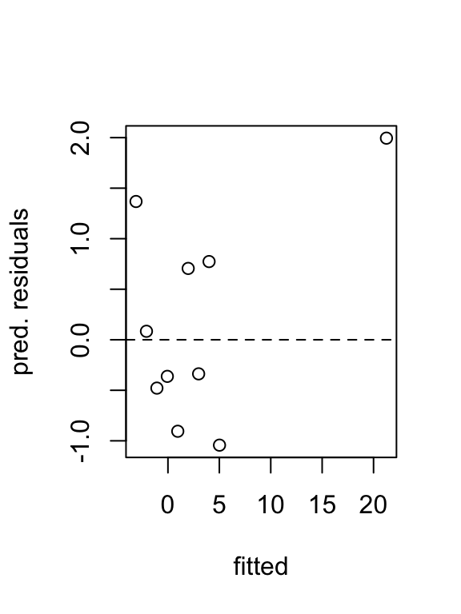

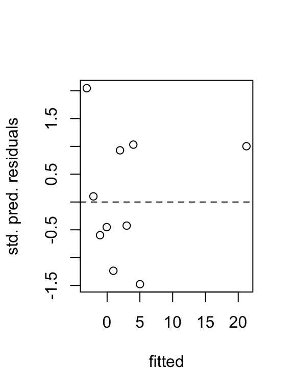

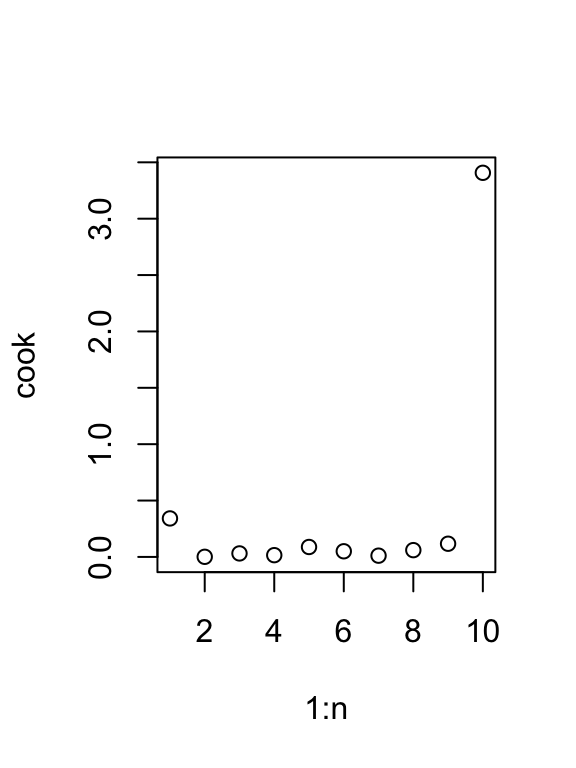

```r
y[n] <- x[n] + 1 + rnorm(1, sd=0.5)
MakePlots(x, y)
```

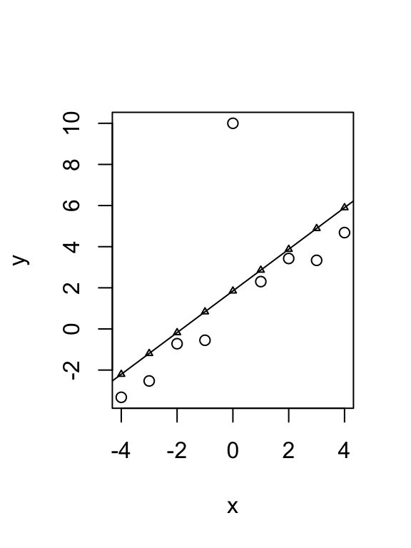

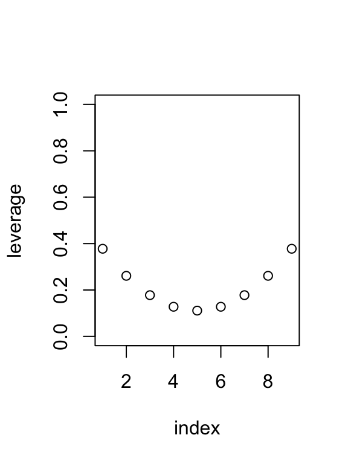

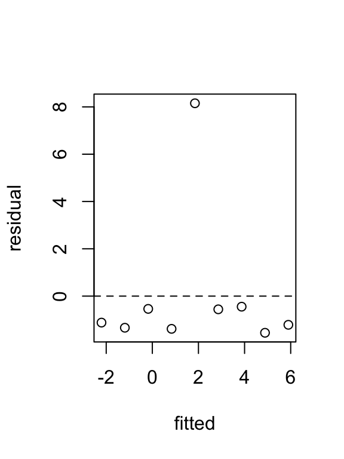

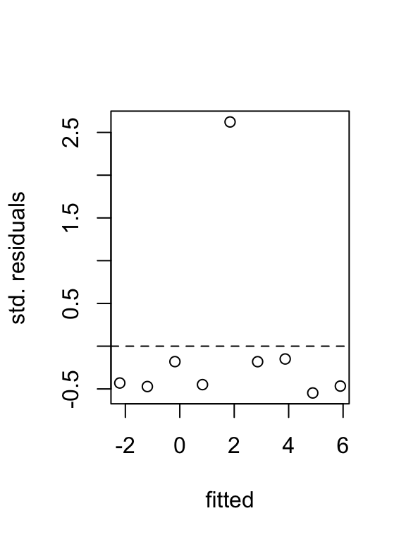

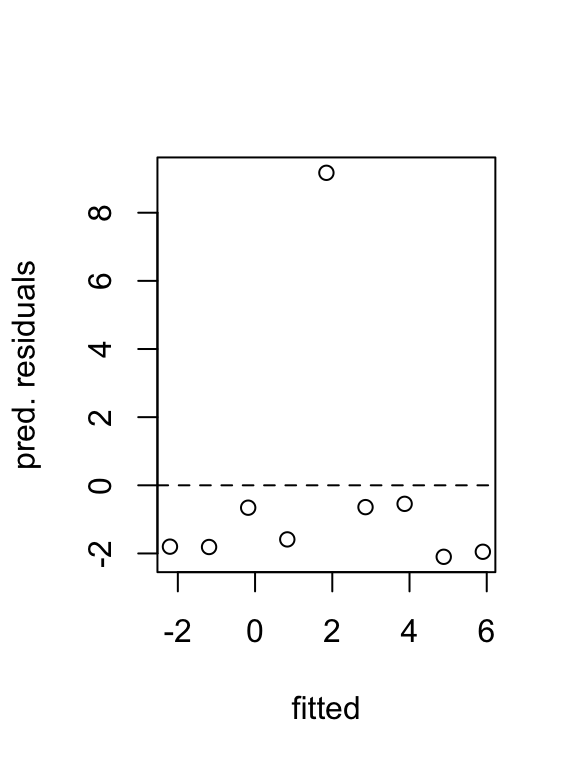

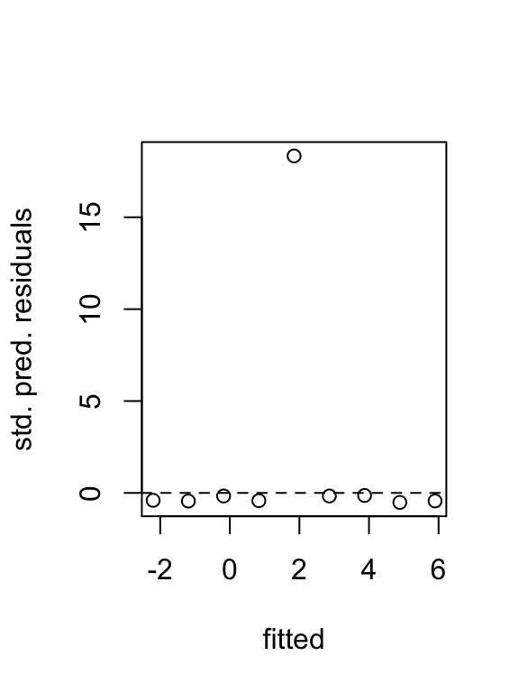

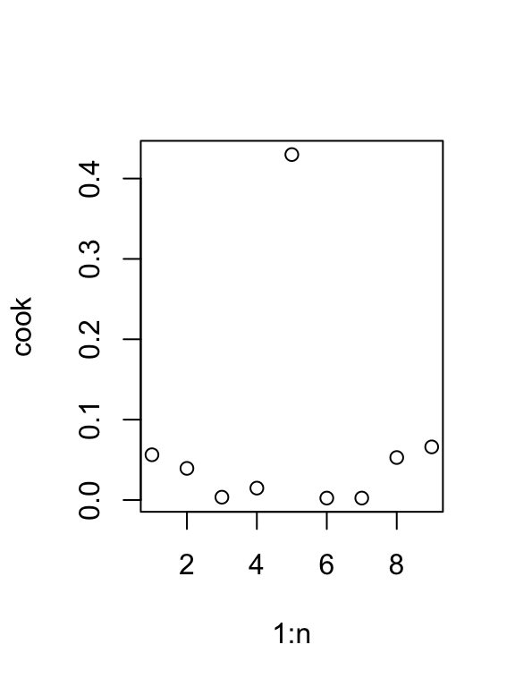

```r
x <- c((-4):4)
n <- length(x)
p <- 1
y <- x + 1 + rnorm(n, sd=0.5)
y[n/2+1] <- 10
MakePlots(x, y)
```

# Testing for outliers

**Read 11.3.1 in Fox.**

[XKCD: Significant](https://xkcd.com/882/)